# Denmark mortality projections

### 2.3.2 Survival Probabilities and Life expectancies

From death probabilities we can obtain 1 year survival probabilities and survival probabilities for many years as well. Then, below is reported the evolution of the life expectancy at age 0 and 65, for the fitted period as well as the projected one.

```r
# one-year survival probability
p_PLAT_DNKm.ext <- 1-q_PLAT_DNKm.ext
# n year survival probability
p0n_PLAT_DNKm.ext <- apply(p_PLAT_DNKm.ext, 2, cumprod)
# from death prob we DNK also obtain life expectancy
ex_PLAT_DNKm.ext <- life.exp(q_PLAT_DNKm.ext)

# the same we DNK do for females
p_PLAT_DNKf.ext <- 1-q_PLAT_DNKf.ext
p0n_PLAT_DNKf.ext <- apply(p_PLAT_DNKf.ext, 2, cumprod)
ex_PLAT_DNKf.ext <- life.exp(q_PLAT_DNKf.ext)
```

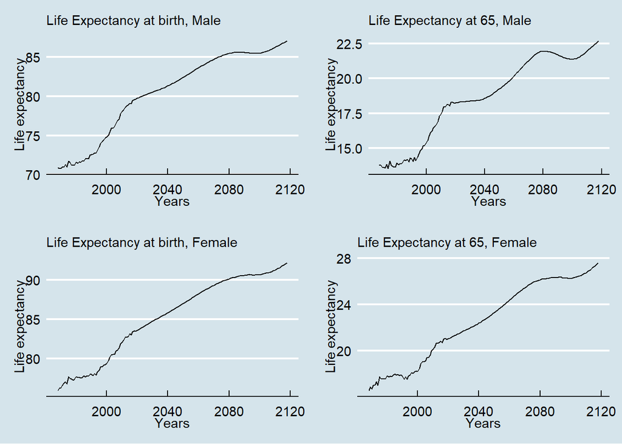

```r
E_birth_m <- ggplot(data=NULL, aes(x = c(1968:2118) , y = ex_PLAT_DNKm.ext[1,])) +
  geom_line() +
  labs(subtitle = "Life Expectancy at birth, Male") +
  xlab("Years") +
  ylab("Life expectancy") +
  theme_economist()

E_65_m <- ggplot(data=NULL, aes(x = c(1968:2118) , y = ex_PLAT_DNKm.ext[66,])) +
  geom_line() +
  labs(subtitle = "Life Expectancy at 65, Male") +
  xlab("Years") +
  ylab("Life expectancy") +
  theme_economist()


E_birth_f <- ggplot(data=NULL, aes(x = c(1968:2118) , y = ex_PLAT_DNKf.ext[1,])) +
  geom_line() +
  labs(subtitle = "Life Expectancy at birth, Female") +
  xlab("Years") +
  ylab("Life expectancy") +
  theme_economist()

E_65_f <- ggplot(data=NULL, aes(x = c(1968:2118) , y = ex_PLAT_DNKf.ext[66,])) +
  geom_line() +
  labs(subtitle = "Life Expectancy at 65, Female") +
  xlab("Years") +
  ylab("Life expectancy") +
  theme_economist()

ggarrange(E_birth_m, E_65_m, E_birth_f, E_65_f)
```

The graphs show an evolution of the life expectancy different from the one of the Lee-Carter model. Indeed, in the case of the Plat model, there is no a linear evolution of life expectancy as in the case of Lee-Carter. This suggests that the PLAT model account for unexpected events, such as epidemics and so on.

### 2.3.3 Evolution of death rates

Up to now it has been considered only the central evolution of death rates. Below are reported the simulated evolution of deaths rates, with the corresponding simulated death probabilities. Then, the evolution of death rates at age 65, 75 and 85 is plotted.

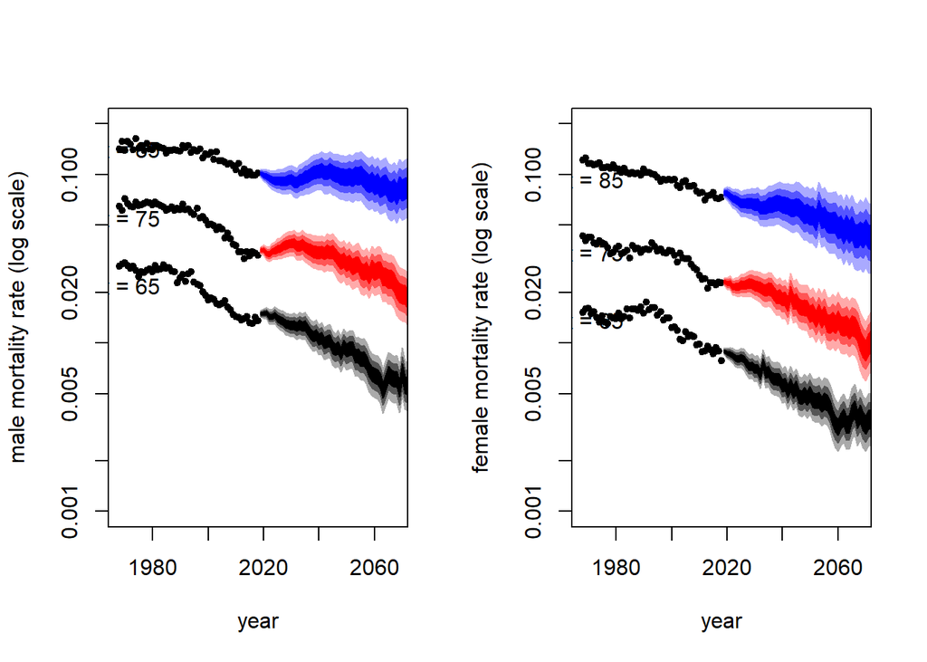

```r
#male
PLATsim_DNKm.mrwd <- simulate(PLATfit_DNKm,
                              nsim = n.sim,
                              h=y.pred,
                              gc.order = c(2, 0, 0))

rates_PLAT_DNKm.st <- PLATsim_DNKm.mrwd$rates
q_PLAT_DNKm.st <- 1- exp(-rates_PLAT_DNKm.st)
q_PLAT_DNKm.st.ext <-  extrapolation.sim(q_PLAT_DNKm.st)

# female
PLATsim_DNKf.mrwd <- simulate(PLATfit_DNKf,
                              nsim = n.sim,
                              h=y.pred,
                              gc.order = c(2, 0, 0))

rates_PLAT_DNKf.st <- PLATsim_DNKf.mrwd$rates
q_PLAT_DNKf.st <- 1- exp(-rates_PLAT_DNKf.st)
q_PLAT_DNKf.st.ext <-  extrapolation.sim(q_PLAT_DNKf.st)

# fun charts
probs = c(2.5, 10, 25, 50, 75, 90, 97.5)
par(mfrow=c(1, 2))
matplot(PLATfit_DNKm$years,
        t(q_PLAT_DNKm[c("65", "75", "85"),
                    c(1:length(Y.fit)) ]),
        xlim = c(y.fit.min, (y.fit.min+y.pred)),
        ylim = c(0.001, 0.2),
        pch = 20, col = "black",
        log = "y",
        xlab = "year",
        ylab = "male mortality rate (log scale)")
fan(t(PLATsim_DNKm.mrwd$rates["65", , ]),
    start = y.fit.max+1,
    probs = probs, n.fan = 4,
    fan.col = colorRampPalette(c("black", "white")),
    ln = NULL)
fan(t(PLATsim_DNKm.mrwd$rates["75", , ]),
    start = y.fit.max+1,
    probs = probs,
    n.fan = 4,
    fan.col = colorRampPalette(c("red", "white")),
    ln = NULL)
fan(t(PLATsim_DNKm.mrwd$rates["85", , ]),
    start = y.fit.max+1,
    probs = probs,
    n.fan = 4,
    fan.col = colorRampPalette(c("blue", "white")),
    ln = NULL)
text(y.fit.min+4,
     q_PLAT_DNKm[c("65", "75", "85"), 30],
     labels = c("x = 65", "x = 75", "x = 85"))
matplot(PLATfit_DNKf$years,
        t(q_PLAT_DNKf[c("65", "75", "85"),
                    c(1:length(Y.fit)) ]),
        xlim = c(y.fit.min, (y.fit.min+y.pred)),
        ylim = c(0.001, 0.2),
        pch = 20, col = "black",
        log = "y", xlab = "year", ylab = "female mortality rate (log scale)")
fan(t(PLATsim_DNKf.mrwd$rates["65", , ]),
    start = y.fit.max+1,
    probs = probs, n.fan = 4,
    fan.col = colorRampPalette(c("black", "white")),
    ln = NULL)
fan(t(PLATsim_DNKf.mrwd$rates["75", , ]),
    start = y.fit.max+1,
    probs = probs,
    n.fan = 4,
    fan.col = colorRampPalette(c("red", "white")),
    ln = NULL)
fan(t(PLATsim_DNKf.mrwd$rates["85", , ]),
    start = y.fit.max+1,
    probs = probs,
    n.fan = 4,
    fan.col = colorRampPalette(c("blue", "white")), ln = NULL)
text(y.fit.min+4,
     q_PLAT_DNKf[c("65", "75", "85"), 30],
     labels = c("x = 65", "x = 75", "x = 85"))
```

### 2.3.4 Bootstrap

Even in the case of the Plat model, a semiparametric bootstrap has been implemented.

```r
PLATboot_DNKm <- bootstrap(PLATfit_DNKm,
                         nBoot = n.boot,
                         type = "semiparametric")
PLATsim_DNKm.boot <- simulate(PLATboot_DNKm, nsim = n.sim/n.boot, h = y.pred)
rates_PLAT_DNKm.boot.st <- PLATsim_DNKm.boot$rates
q_PLAT_DNKm.boot.st <- 1- exp(-rates_PLAT_DNKm.boot.st)
q_PLAT_DNKm.boot.st.ext <-  extrapolation.sim(q_PLAT_DNKm.boot.st)

PLATboot_DNKf <- bootstrap(PLATfit_DNKf,
                         nBoot = n.boot,
                         type = "semiparametric")
PLATsim_DNKf.boot <- simulate(PLATboot_DNKf, nsim = n.sim/n.boot, h = y.pred)
rates_PLAT_DNKf.boot.st <- PLATsim_DNKf.boot$rates
q_PLAT_DNKf.boot.st <- 1- exp(-rates_PLAT_DNKf.boot.st)
q_PLAT_DNKf.boot.st.ext <-  extrapolation.sim(q_PLAT_DNKf.boot.st)


# Confidence intervals at 90%

# we DNK represent the confidence intervals for the death probs and store them in a df.
# 1 year death probability
conf.lev <- 0.9
q_PLAT_DNKm.q95 <- matrix(0, nrow=(omega-a.min),ncol=y.pred, dimnames=list(c(a.min:(omega-1)), c((tail(Y.fit,1)+1):(tail(Y.fit,1)+y.pred))))
q_PLAT_DNKm.q05 <- matrix(0, nrow=(omega-a.min),ncol=y.pred, dimnames=list(c(a.min:(omega-1)), c((tail(Y.fit,1)+1):(tail(Y.fit,1)+y.pred))))
q_PLAT_DNKm.boot.q95 <- matrix(0, nrow=(omega-a.min),ncol=y.pred, dimnames=list(c(a.min:(omega-1)), c((tail(Y.fit,1)+1):(tail(Y.fit,1)+y.pred))))
q_PLAT_DNKm.boot.q05 <- matrix(0, nrow=(omega-a.min),ncol=y.pred, dimnames=list(c(a.min:(omega-1)), c((tail(Y.fit,1)+1):(tail(Y.fit,1)+y.pred))))

for (j in 1:(omega-a.min)){
  for (k in 1:y.pred){
    q_PLAT_DNKm.q95[j,k] <- quantile(q_PLAT_DNKm.st.ext[j,k,],
                                   probs=0.5+conf.lev/2)
    q_PLAT_DNKm.q05[j,k] <- quantile(q_PLAT_DNKm.st.ext[j,k,],
                                   probs=(1-conf.lev)/2)
    q_PLAT_DNKm.boot.q95[j,k] <- quantile(q_PLAT_DNKm.boot.st.ext[j,k,],
                                        probs=0.5+conf.lev/2)
    q_PLAT_DNKm.boot.q05[j,k] <- quantile(q_PLAT_DNKm.boot.st.ext[j,k,],
                                        probs=(1-conf.lev)/2)
  }
}

q_PLAT_DNKf.q95 <- matrix(0, nrow=(omega-a.min),ncol=y.pred, dimnames=list(c(a.min:(omega-1)), c((tail(Y.fit,1)+1):(tail(Y.fit,1)+y.pred))))
q_PLAT_DNKf.q05 <- matrix(0, nrow=(omega-a.min),ncol=y.pred, dimnames=list(c(a.min:(omega-1)), c((tail(Y.fit,1)+1):(tail(Y.fit,1)+y.pred))))
q_PLAT_DNKf.boot.q95 <- matrix(0, nrow=(omega-a.min),ncol=y.pred, dimnames=list(c(a.min:(omega-1)), c((tail(Y.fit,1)+1):(tail(Y.fit,1)+y.pred))))
q_PLAT_DNKf.boot.q05 <- matrix(0, nrow=(omega-a.min),ncol=y.pred, dimnames=list(c(a.min:(omega-1)), c((tail(Y.fit,1)+1):(tail(Y.fit,1)+y.pred))))
for (j in 1:(omega-a.min)){
  for (k in 1:y.pred){
    q_PLAT_DNKf.q95[j,k] <- quantile(q_PLAT_DNKf.st.ext[j,k,], probs=0.5+conf.lev/2)
    q_PLAT_DNKf.q05[j,k] <- quantile(q_PLAT_DNKf.st.ext[j,k,], probs=(1-conf.lev)/2)
    q_PLAT_DNKf.boot.q95[j,k] <- quantile(q_PLAT_DNKf.boot.st.ext[j,k,], probs=0.5+conf.lev/2)
    q_PLAT_DNKf.boot.q05[j,k] <- quantile(q_PLAT_DNKf.boot.st.ext[j,k,], probs=(1-conf.lev)/2)
  }
}
```

### 2.3.5 Actuarial quantities

#### 2.3.5.1 death probabilities at 65

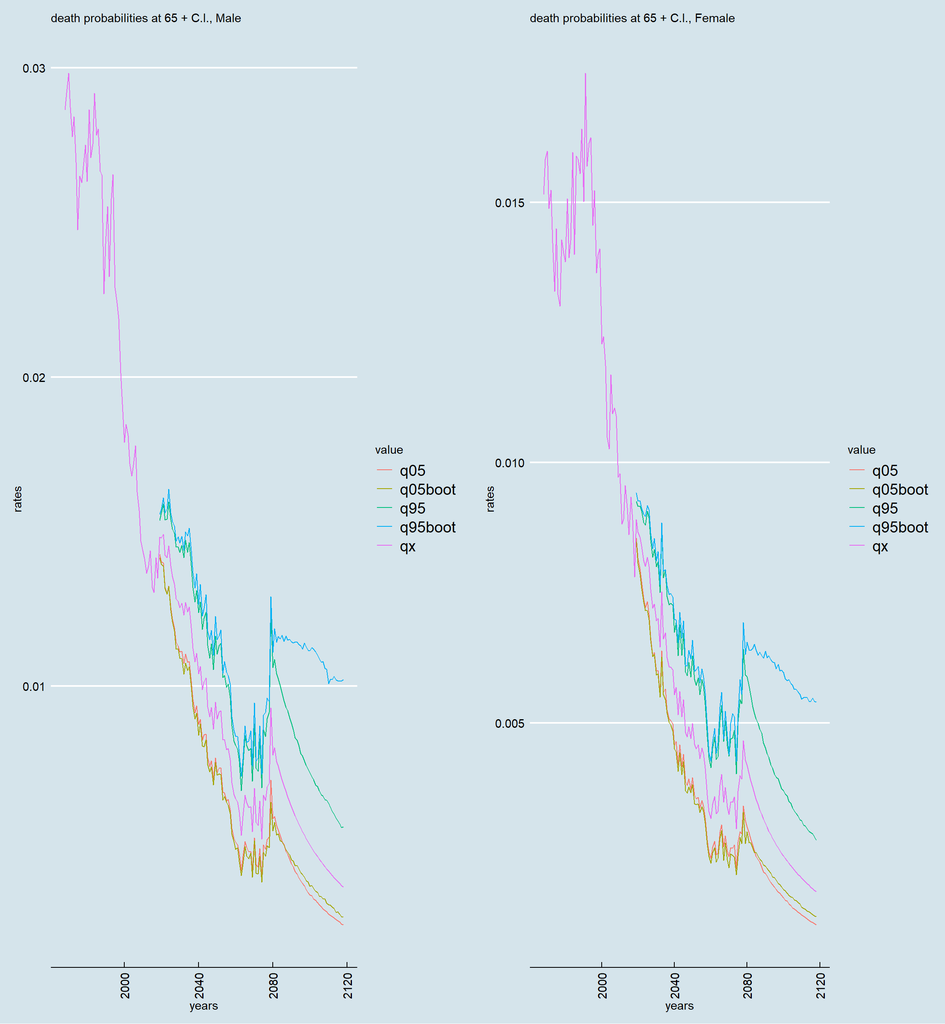

```r
# data preparation
death_probs_ci_m <- tibble(q95 = q_PLAT_DNKm.q95["65",],
                           q05 = q_PLAT_DNKm.q05["65",],
                           q95boot = q_PLAT_DNKm.boot.q95["65",],
                           q05boot = q_PLAT_DNKm.boot.q05["65",],
                           years =seq(2019,2118),
                           )


death_probs_ci_m <- death_probs_ci_m %>%  gather("value", "rates", 1:4)

death_prob_m <- tibble(years = seq(1968,2118),
                     value = "qx",
                     rates = q_PLAT_DNKm.ext["65",]
                     )

death_probs_ci_f <- tibble(q95 = q_PLAT_DNKf.q95["65",],
                           q05 = q_PLAT_DNKf.q05["65",],
                           q95boot = q_PLAT_DNKf.boot.q95["65",],
                           q05boot = q_PLAT_DNKf.boot.q05["65",],
                           years =seq(2019,2118),
                           )


death_probs_ci_f <- death_probs_ci_f %>%  gather("value", "rates", 1:4)

death_prob_f <- tibble(years = seq(1968,2118),
                     value = "qx",
                     rates = q_PLAT_DNKf.ext["65",]
                     )

data_deaths_m <- rbind(death_prob_m, death_probs_ci_m)
data_deaths_f <- rbind(death_prob_f, death_probs_ci_f)

d_p_m <- ggplot(data = data_deaths_m) +
  geom_line( aes(x = years, y = rates, colour = value)) +
   theme_economist() +
  labs(subtitle = "death probabilities at 65 + C.I., Male") +
  theme(legend.position = "right",
        axis.text.x = element_text(angle = 90, vjust = 0.5, hjust=1))


d_p_f <- ggplot(data = data_deaths_f) +
  geom_line( aes(x = years, y = rates, colour = value)) +
   theme_economist() +
  labs(subtitle = "death probabilities at 65 + C.I., Female") +
  theme(legend.position = "right",
        axis.text.x = element_text(angle = 90, vjust = 0.5, hjust=1))



ggarrange(d_p_m, d_p_f)
```

#### 2.3.5.2 death probabilities at age 20

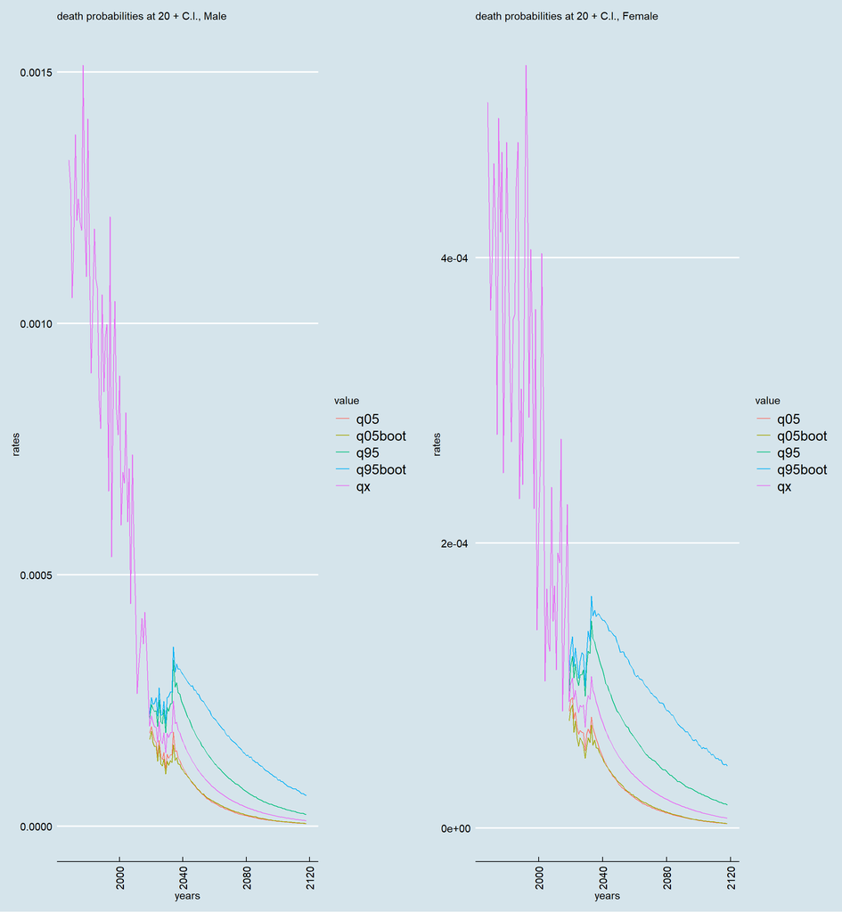

```r
# data preparation
death_probs_ci_m <- tibble(q95 = q_PLAT_DNKm.q95["20",],
                           q05 = q_PLAT_DNKm.q05["20",],
                           q95boot = q_PLAT_DNKm.boot.q95["20",],
                           q05boot = q_PLAT_DNKm.boot.q05["20",],
                           years =seq(2019,2118),
                           )


death_probs_ci_m <- death_probs_ci_m %>%  gather("value", "rates", 1:4)

death_prob_m <- tibble(years = seq(1968,2118),
                     value = "qx",
                     rates = q_PLAT_DNKm.ext["20",]
                     )

death_probs_ci_f <- tibble(q95 = q_PLAT_DNKf.q95["20",],
                           q05 = q_PLAT_DNKf.q05["20",],
                           q95boot = q_PLAT_DNKf.boot.q95["20",],
                           q05boot = q_PLAT_DNKf.boot.q05["20",],
                           years =seq(2019,2118),
                           )


death_probs_ci_f <- death_probs_ci_f %>%  gather("value", "rates", 1:4)

death_prob_f <- tibble(years = seq(1968,2118),
                     value = "qx",
                     rates = q_PLAT_DNKf.ext["20",]
                     )

data_deaths_m <- rbind(death_prob_m, death_probs_ci_m)
data_deaths_f <- rbind(death_prob_f, death_probs_ci_f)

d_p_m <- ggplot(data = data_deaths_m) +
  geom_line( aes(x = years, y = rates, colour = value)) +
   theme_economist() +
  labs(subtitle = "death probabilities at 20 + C.I., Male") +
  theme(legend.position = "right",
        axis.text.x = element_text(angle = 90, vjust = 0.5, hjust=1))


d_p_f <- ggplot(data = data_deaths_f) +
  geom_line( aes(x = years, y = rates, colour = value)) +
   theme_economist() +
  labs(subtitle = "death probabilities at 20 + C.I., Female") +
  theme(legend.position = "right",
        axis.text.x = element_text(angle = 90, vjust = 0.5, hjust=1))



ggarrange(d_p_m, d_p_f)
```

#### 2.3.5.3 Present values of stochastic annuities

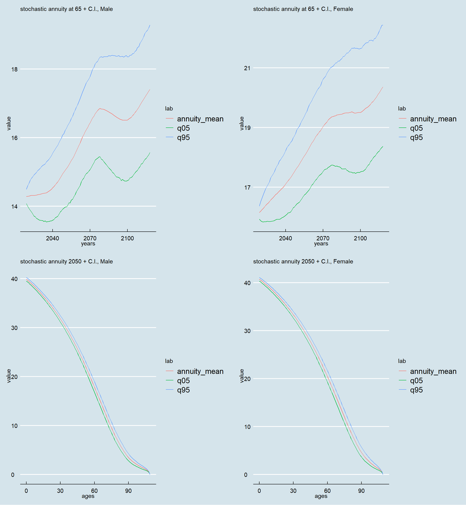

```r
p_PLAT_DNKm.st.ext <- 1-q_PLAT_DNKm.st.ext # 1 year survival probability
ann_PLAT_DNKm.st <- annuity.st(q_PLAT_DNKm.st.ext,v_vect,0.9)
ann_PLAT_DNKm.mean <- ann_PLAT_DNKm.st[[1]]
ann_PLAT_DNKm.q95 <- ann_PLAT_DNKm.st[[2]]
ann_PLAT_DNKm.q05 <- ann_PLAT_DNKm.st[[3]]

p_PLAT_DNKf.st.ext <- 1-q_PLAT_DNKf.st.ext # 1 year survival probability
ann_PLAT_DNKf.st <- annuity.st(q_PLAT_DNKf.st.ext,v_vect,0.9)
ann_PLAT_DNKf.mean <- ann_PLAT_DNKf.st[[1]]
ann_PLAT_DNKf.q95 <- ann_PLAT_DNKf.st[[2]]
ann_PLAT_DNKf.q05 <- ann_PLAT_DNKf.st[[3]]

# data preparation

annuity_male <- tibble(annuity_mean = ann_PLAT_DNKm.mean["65",],
                       q05 = ann_PLAT_DNKm.q05["65",],
                       q95 = ann_PLAT_DNKm.q95["65",],
                       years = seq(2019,2118))

annuity_male <- annuity_male %>% gather("lab", "value", 1:3)

annuity_female <- tibble(annuity_mean = ann_PLAT_DNKf.mean["65",],
                       q05 = ann_PLAT_DNKf.q05["65",],
                       q95 = ann_PLAT_DNKf.q95["65",],
                       years = seq(2019,2118))

annuity_female <- annuity_female %>% gather("lab", "value", 1:3)


ann_2050_m <- tibble(annuity_mean = ann_PLAT_DNKm.mean[,"2050"],
                       q05 = ann_PLAT_DNKm.q05[,"2050"],
                       q95 = ann_PLAT_DNKm.q95[,"2050"],
                       ages = seq(0,109))

annuity_2050_m <- ann_2050_m %>% gather("lab", "value", 1:3)

ann_2050_f <- tibble(annuity_mean = ann_PLAT_DNKf.mean[,"2050"],
                       q05 = ann_PLAT_DNKf.q05[,"2050"],
                       q95 = ann_PLAT_DNKf.q95[,"2050"],
                       ages = seq(0,109))

annuity_2050_f <- ann_2050_f %>% gather("lab", "value", 1:3)



an_male <- ggplot(data = annuity_male) +
  geom_line(aes(x = years, y = value, color = lab)) +
   theme_economist() +
  labs(subtitle = "stochastic annuity at 65 + C.I., Male") +
  theme(legend.position = "right")

an_fem <- ggplot(data = annuity_female) +
  geom_line(aes(x = years, y = value, color = lab)) +
   theme_economist() +
  labs(subtitle = "stochastic annuity at 65 + C.I., Female") +
  theme(legend.position = "right")


an_male_2050 <- ggplot(data = annuity_2050_m) +
  geom_line(aes(x = ages, y = value, color = lab)) +
   theme_economist() +
  labs(subtitle = "stochastic annuity 2050 + C.I., Male") +
  theme(legend.position = "right")

an_female_2050 <- ggplot(data = annuity_2050_f) +
  geom_line(aes(x = ages, y = value, color = lab)) +
   theme_economist() +
  labs(subtitle = "stochastic annuity 2050 + C.I., Female") +
  theme(legend.position = "right")

ggarrange(an_male, an_fem, an_male_2050, an_female_2050)
```